# Raport_5

Magdalena Wawrzyniak

## Zadanie 1

Przeprowadzamy regresję liniową dla danych, w których zmienną objaśnianą jest poziom satysfakcji, a zmiennymi objaśniającymi są wiek, ciężkość choroby, poziom lęku. Wgrywamy dane a następnie tworzymy model przy pomocy funkcji `lm`.

Dopasowane równanie regresji liniowej jest postaci:

$\hat{Y} =$ 1.0532 - 0.0059$X_1$ + 0.0019$X_2$ + 0.0301$X_3$

**Współczynnik determinacji** $R^2 =$ 0.5415482, stąd wiemy, że model mógłby być lepiej dopasowany do naszych danych.

Testujemy nasz model i sprawdzamy istotność trzech zmiennych objaśniających.

$H_0: \beta_1 = \beta_2 = \beta_3 = 0$ vs $H_1: \beta_1 \neq 0$ v $\beta_2 \neq 0$ v $\beta_3 \neq 0$ §

**Wartość statystyki testowej** $F =$ 16.5375621, na **poziomie istotności** 0.95 i **stopniami swobody** 3, 42 oraz **p-wartością** bliską 0.

**Wniosek:** Odrzucamy hipotezę zerową i przyjmujemy hipotezę alternatywną, czyli zmienna objaśniana zależy od przynajmniej od jednej zmiennej niezależnej.

## Zadanie 2

Przedziału ufności na poziomie istotności 0.95 dla zmiennych z modelu:

```r
confint(model_satysfakcji)
```

```
##                        2.5 %       97.5 %
## (Intercept)      -0.18543590 2.2919261589
## Wiek             -0.01209411 0.0003730895
## Ciężkość_choroby -0.00974994 0.0136060385
## Poziom_lęku       0.01146717 0.0488283055
```

Stworzymy modele regresji prostej osobno dla wieku, cięzkości choroby oraz poziomu lęku, a następnie przeprowadzimy testy.

### Wiek

Dopasowane równanie regresji liniowej prostej:

$\hat{Y} =$ 2.9761 - 0.0112$X_1$

Testujemy nasz model i sprawdzamy istotność trzech zmiennych objaśniających.

$H_0: \beta_1 = 0$ vs $H_1: \beta_1 \neq 0$

Dostajemy następującą statystykę testową F 31.2776993 z 1, 44 stopniami swobody oraz p-wartością równą około 0.

**Wniosek:** Odrzucamy hipotezę zerową i przyjmujemy hipotezę alternatywną. Poziom satysfakcji zależy od od wieku.

### Ciężkość choroby

Testujemy nasz model i sprawdzamy istotność trzech zmiennych objaśniających.

$H_0: \beta_1 = 0$ vs $H_1: \beta_1 \neq 0$

Dostajemy następującą statystykę testową F 21.1400632 z 1, 44 stopniami swobody oraz p-wartością równą około 0.

**Wniosek:** Odrzucamy hipotezę zerową i przyjmujemy hipotezę alternatywną. Poziom satysfakcji zależy od od ciężkości choroby.

### Poziom lęku

Testujemy nasz model i sprawdzamy istotność trzech zmiennych objaśniających.

$H_0: \beta_1 = 0$ vs $H_1: \beta_1 \neq 0$

Dostajemy następującą statystykę testową F 35.9431203 z 1, 44 stopniami swobody oraz p-wartością równą około 0.

**Wniosek:** Odrzucamy hipotezę zerową i przyjmujemy hipotezę alternatywną. Poziom satysfakcji zależy od od poziomu lęku.

## Zadanie 3

**Wykres reszt**

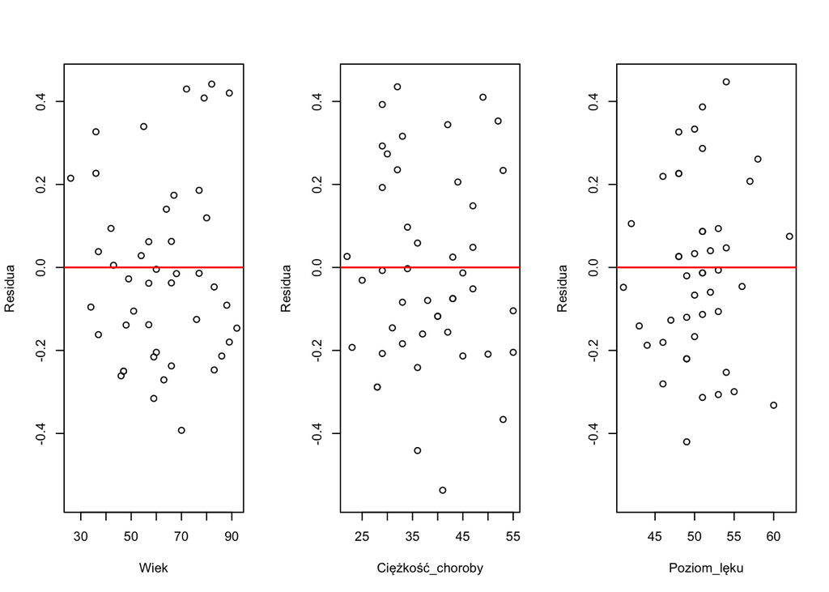

**Wniosek:** Nie widać na wykresie żadnych nietypowych wzorców ani wartości odstających.

## Zadanie 4

Sprawdzimy teraz czy residua mają rozkład w przybliżeniu normalny korzystając funkcji kwantylowo-kwantylowej (Q-Q plot) oraz z testu Shapiro-Wilka, gdzie:

$H_0:$ Próba pochodzi z populacji o rozkładzie normalnym.

$H_1:$ Próba nie pochodzi z populacji o rozkładzie normalnym.

```
##
##  Shapiro-Wilk normality test
##
## data:  summ_wiek$residuals
## W = 0.94686, p-value = 0.03554
```

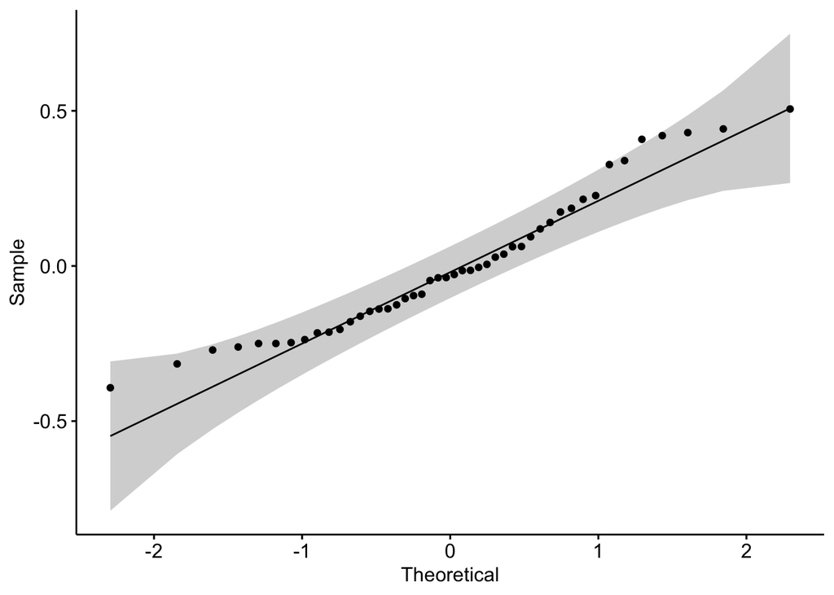

**Wniosek:** Odrzucamy hipotezę zerową i przyjmujemy alternatywną, czyli residua nie pochodzą z rozkładu normalnego. Patrząc na wykres kwantylowo-kwantylowy możemy stwierdzić, że nasze dane mają bardziej odstające wartości, niż można by się spodziewać, gdyby naprawdę pochodziły z rozkładu normalnego.

```
##
##  Shapiro-Wilk normality test
##
## data:  summ_cc$residuals
## W = 0.97342, p-value = 0.3689
```

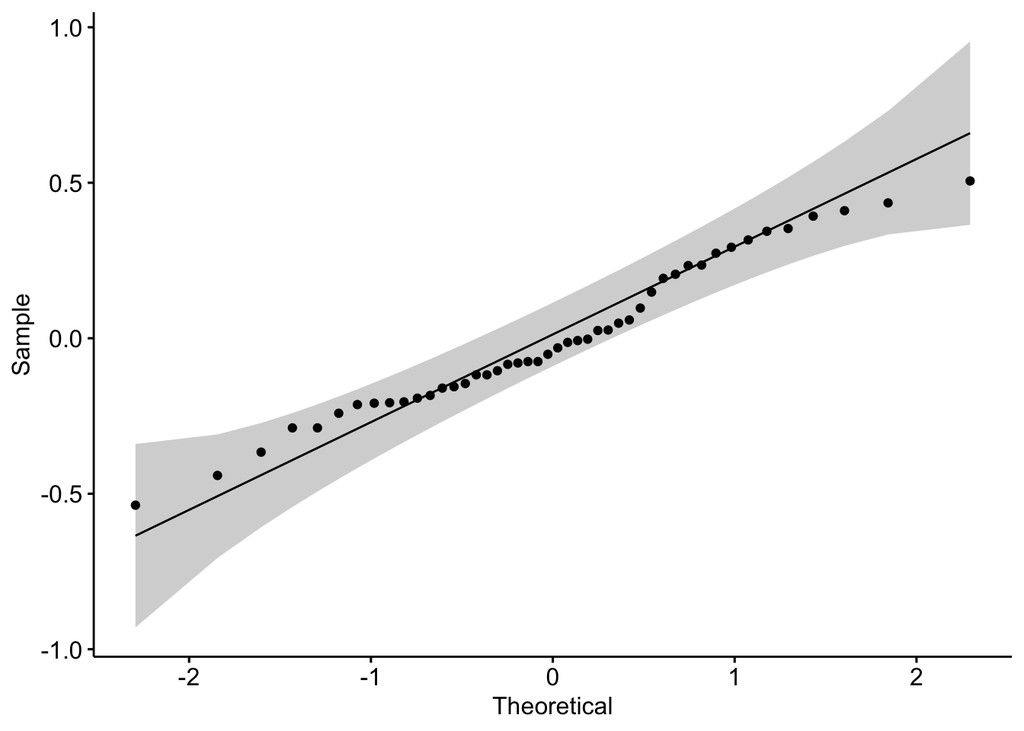

**Wniosek:** Nie mamy podstaw do odrzucenia hipotezy zerowej, residua mogą mieć rozkład normalny. Na wykresie dane oscylują w pobliżu prostej, co wskazuje na to, że mogą pochodzić z rozkładu normalnego.

```
##
##  Shapiro-Wilk normality test
##
## data:  summ_pl$residuals
## W = 0.97979, p-value = 0.5973
```

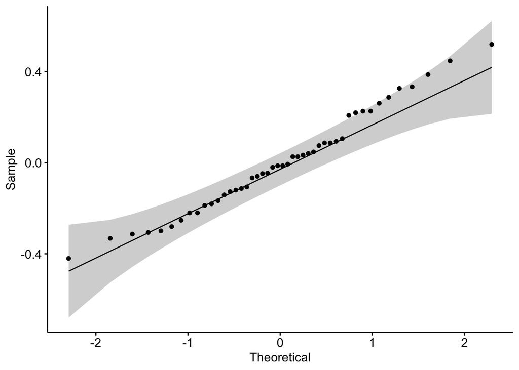

**Wniosek:** Nie mamy podstaw do odrzucenia hipotezy zerowej, residua mogą mieć rozkład normalny. Na wykresie dane oscylują w pobliżu prostej, co wskazuje na to, że mogą pochodzić z rozkładu normalnego.

## Zadanie 5

Modelem pełnym (ozn. model_F) będziemy nazywali model z pięcioma zmiennymi objaśniającymi ($HSM$, $HSS$, $HSE$, $SATM$, $SATV$), a modelem zredukowanym (ozn. model_R) model z 3 zmiennymi ($HSM$, $HSS$, $HSE$). Niech $n$ oznacza liczebność prób, a $p$ ilość parametrów modelu.

### a)

Konstruujemy ręcznie statystykę F, wykorzystując różnicę między SSE dla modeli zredukowanego i pełnego, aby przetestować hipotezy:

$H_0: \beta_4 = \beta_5 = 0$ vs $H_1: \beta_4 \neq 0$ v $\beta_5 \neq 0$.

Wzór, którego używamy do podania statystyki F wygląda następująco:

$$F = \frac{SSE_R - SSE_F}{(dfE_R - dfE_F)
MSE_F}.$$

```r
# Wyliczenia ręczne dla modelu R
SSE_R <- sum((GPA - est_GPA_R)^2)
SST_R <- sum((GPA - mean(GPA))^2)
SSM_R <- SST_R - SSE_R
dfE_R <- n - p_R
dfM_R <- p_R - 1
MSE_R <- SSE_R/dfE_R
MSM_R <- SSM_R/dfM_R

# Wyliczenia ręczne dla modelu F
SSE_F <- sum((GPA - est_GPA_F)^2)
SST_F <- SST_R
SSM_F <- SST_F - SSE_F
dfE_F <- n - p_F
dfM_F <- p_F - 1
MSE_F <- SSE_F/dfE_F
MSM_F <- SSM_F/dfM_F

# różnica między SSE z modelu R i F
differ <- SSE_R - SSE_F

stat_F <- (differ/(dfE_R - dfE_F))/MSE_F
```

Różnicę między SSE obu modeli jest równa 0.9313136, natomiast statystyka $F =$ 0.9503276.

### b)

Dla tego samego testu bierzemy statystykę F, wykorzystując `anova`.

```r
anova_R <- anova(model_R)
anova_F <- anova(model_F)

anova_SSE_F <- anova_F$`Sum Sq`[p_F] # SSE wyliczone z ANOVA z R dla modelu F
anova_SSE_R <- anova_R$`Sum Sq`[p_R] # SSE wyliczone z ANOVA z R dla modelu R
anova_MSE_F <- anova_SSE_F/anova_F$Df[p_F]

anova_stat_F <- ((anova_SSE_R - anova_SSE_F)/
                   (anova_R$Df[p_R] - anova_F$Df[p_F]))/anova_MSE_F
```

Wartość statystyki F z wykorzystaniem anova wynosi 0.9503276. Widzimy, że wyniki jakie otrzmaliśmy są takie same. Teraz wyliczamy kwantyl z rozkładu Fishera-Snedecora, z liczbą stopni swobody 2 i 218, a następnie porównujemy z otrzymaną statystyką.

```r
fc = qf(0.95, anova_R$Df[p_R] - anova_F$Df[p_F], anova_F$Df[p_F])

anova_stat_F > fc
```

```
## [1] FALSE
```

**Wniosek:** Nie mamy podstaw aby odrzucić hipotezę zerową. Oznacza to, że nadal nie wiemy cze zmienne $SATV$ i $SATM$ są istotne w naszym modelu.

## Zadanie 6

Anova zwraca sumy kwadratów typu 1, natomiast sumy kwadratów typu 2 możemy wyliczać ręcznie możemy to liczyć ręcznie ze wzoru. Różnica między typami wygląda tak, jak na przyladzie poniżej.

Suma II typu:

```
          SSM(Xi| X1, ..., X(i-1), X(i+1),...,Xn)
```

Suma I typu:

```
          SSM(X1)

          SSM(X2|X1)

          SSM(X3|X2, X1)

          (...)
```

Za pomocą odpowiednich przekształceń dostajemy tabelę sum kwadratów 1 i 2 typu:

```
##         typ.1   typ.2
## SATM  8.58293 0.92800
## SATV  0.00091 0.23265
## HSM  17.72647 6.77243
## HSE   1.89119 0.95680
## HSS   0.44214 0.44214
```

### a)

Tworzymy dwa modele regresji jeden ze zmiennymi $SATM$, $SATV$, $HSM$, a drugi bez HSM. Chcemy sprawdzić czy różnica sum kwadratów dla obu modeli da nam różnicę sumy kwadratów typu 1 dla $HSM$.

```r
# a)
model_2 <- lm(GPA ~ SATM + SATV)
model_3 <- lm(GPA ~ SATM + SATV + HSM)

a2 <- anova(model_2)
a3 <- anova(model_3)
a2
```

```
## Analysis of Variance Table
##
## Response: GPA
##            Df  Sum Sq Mean Sq F value    Pr(>F)
## SATM        1   8.583  8.5829 14.9499 0.0001452 ***
## SATV        1   0.001  0.0009  0.0016 0.9683570
## Residuals 221 126.879  0.5741
## ---
## Signif. codes:  0 '***' 0.001 '**' 0.01 '*' 0.05 '.' 0.1 ' ' 1
```

```r
a3
```

```
## Analysis of Variance Table
##
## Response: GPA
##            Df  Sum Sq Mean Sq F value    Pr(>F)
## SATM        1   8.583  8.5829 17.2992 4.578e-05 ***
## SATV        1   0.001  0.0009  0.0018     0.966
## HSM         1  17.726 17.7265 35.7282 9.060e-09 ***
## Residuals 220 109.152  0.4961
## ---
## Signif. codes:  0 '***' 0.001 '**' 0.01 '*' 0.05 '.' 0.1 ' ' 1
```

```
##   SSM(HSM|SATM, SATV) SSM(F) - SSM(R) równe
## 1            17.72647        17.72647  TRUE
```

**Wnioski:** Udało nam się pokazać, że różnica SSE modelu zredukowanego i modelu pełnego daje SSE zmiennej, która występowała tylko w jednym z nich. Analogicznie działa to, gdy mówimy o SSM, co wynika z tw. Pitagorasa.

### b)

**Wniosek:** Predyktory dla których wartości SS1 i SS2 są takie same istnieją i są to zawsze ostatnie te które leżą w ostatniej kolumnie macierzy planu. Z definicji SS1 i SS2 wynika, że wyrażone są tym samym wzorem.

## Zadanie 7

Chcemy zbadać co się stanie, gdyby jedna zmienna w modelu była kombinacją liniową pozostałych. W tym celu tworzymy model, w którym zmiennymi objaśniającymi są $SATV$, $SATM$ oraz $SAT = SATM + SATV$.

```
##
## Call:
## lm(formula = GPA ~ SATM + SATV + SAT)
##
## Residuals:
##      Min       1Q   Median       3Q      Max
## -2.59483 -0.37920  0.08263  0.55730  1.39931
##
## Coefficients: (1 not defined because of singularities)
##               Estimate Std. Error t value Pr(>|t|)
## (Intercept)  1.289e+00  3.760e-01   3.427 0.000728 ***
## SATM         2.283e-03  6.629e-04   3.444 0.000687 ***
## SATV        -2.456e-05  6.185e-04  -0.040 0.968357
## SAT                 NA         NA      NA       NA
## ---
## Signif. codes:  0 '***' 0.001 '**' 0.01 '*' 0.05 '.' 0.1 ' ' 1
##
## Residual standard error: 0.7577 on 221 degrees of freedom
## Multiple R-squared:  0.06337,    Adjusted R-squared:  0.05489
## F-statistic: 7.476 on 2 and 221 DF,  p-value: 0.0007218
```

Dla jednej ze zmiennych (z ostatniej kolumny macierzy planu) zawsze wychodziło `Na` (niezależnie od kolejności występowania zmiennych w modelu). Może być to spowodowane tym, że zmienna jest kombinacją liniową dwóch poprzednich kolumn i prawdopodobnie R sam wyklucza ją z modelu.

Jeżeli stworzymy model bez zmiennej $SAT$, otrzymujemy:

```
##
## Call:
## lm(formula = GPA ~ SATM + SATV)
##
## Residuals:
##      Min       1Q   Median       3Q      Max
## -2.59483 -0.37920  0.08263  0.55730  1.39931
##
## Coefficients:
##               Estimate Std. Error t value Pr(>|t|)
## (Intercept)  1.289e+00  3.760e-01   3.427 0.000728 ***
## SATM         2.283e-03  6.629e-04   3.444 0.000687 ***
## SATV        -2.456e-05  6.185e-04  -0.040 0.968357
## ---
## Signif. codes:  0 '***' 0.001 '**' 0.01 '*' 0.05 '.' 0.1 ' ' 1
##
## Residual standard error: 0.7577 on 221 degrees of freedom
## Multiple R-squared:  0.06337,    Adjusted R-squared:  0.05489
## F-statistic: 7.476 on 2 and 221 DF,  p-value: 0.0007218
```

Widzimy, że wyniki jakie otrzymaliśmy są takie same jak w modelu powyżej.

**Wniosek:** Jeżeli zmienna niezależna jest kombinacja liniową pozostałych, to R nie uwzględni jej w modelu. Stworzy on jednak regresję bez tej zmiennej i zaznaczy za pomocą `Na`, że nie występuje ona w modelu.

## Zadanie 8

W tym i następnych zadaniach analizujemy pełny model, którego równanie regresji jest postaci:

$\hat{Y} =$ 0.27864 - 0.14423$X_1$ + 0.05103$X_2$ + 0.03827$X_3$ + 0.001$X_4$ + 4.1^{-4}$X_5$ + 0.03237$X_6$,

gdzie {X_i} to kolejno HSM, HSE, HSS, SATM, SATV, SEX.

Wektor residuów opisuje, to czego nie wyjaśniły zmienne objaśniające, zatem cząstkowy wykres rozrzutu (dla zmiennej $X_i$) opisuje relacje między $X_i$, a $Y$ po uwzględnieniu wpływu pozostałych zmiennych niezależnych. Przykłady:

1. Jeżeli na wykresie nie obserwowana jest żadna wyrażna struktur, oznacza to,że zmienna $X_i$ nie wnosi do modelu istotnej informacji ponad to co wniosły pozostałe $X$.
2. Jeżeli obserwujemy relację liniową (rosnącą/malejącą) oznacza to, że zmienna wnosi dodatkową informację do modelu.
3. Możemy szukać odstępstw od założeń modelu, np. obserwacje odstające, brak liniowości, brak stałości wariancji.

### Partial regression plots

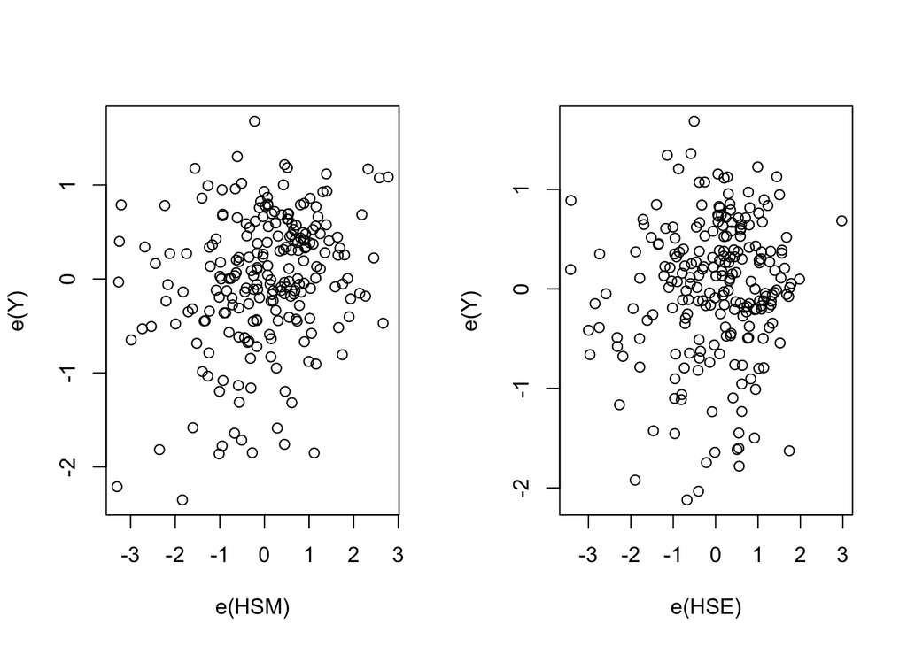

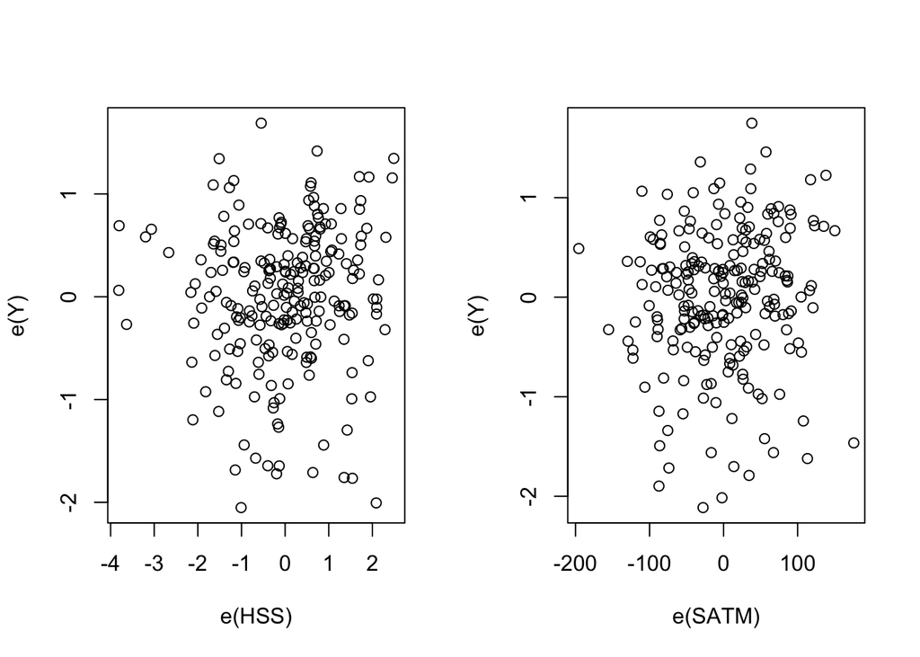

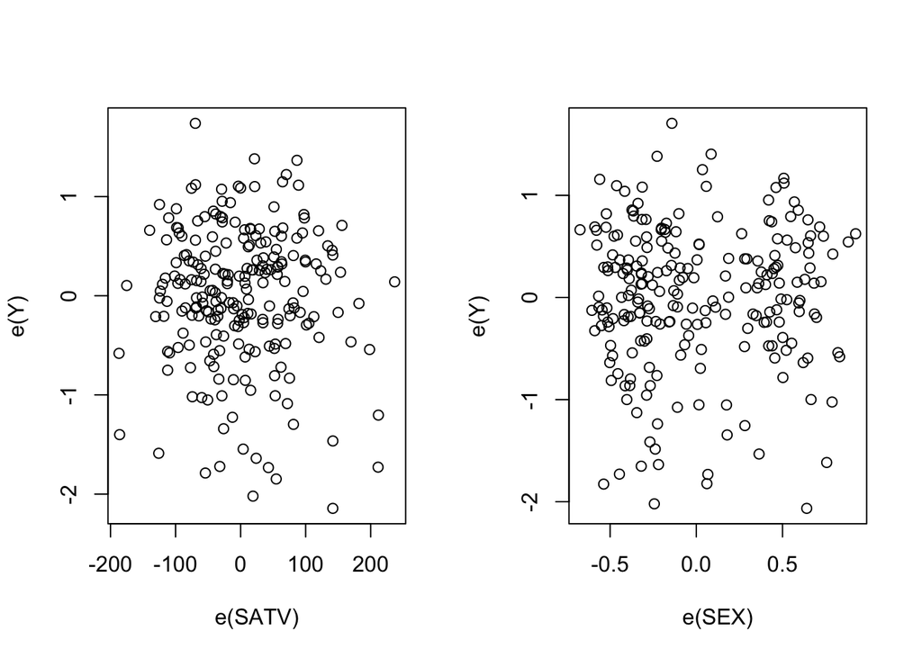

## Zadanie 9

Badamy studentyzowane residua zewnętrzne dla modelu pełnego z zadania 8.

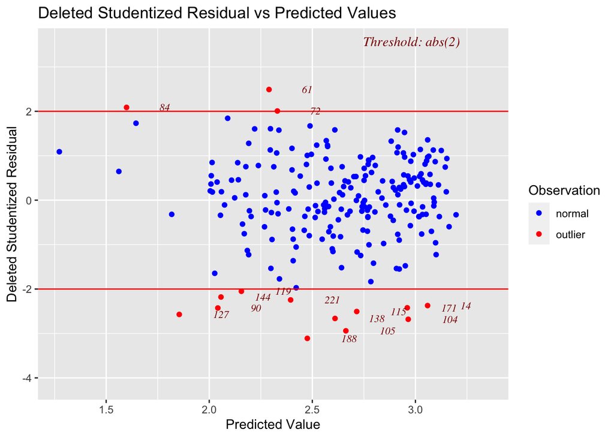

## Zadanie 10

Miara DFFITS dla i–tej obserwacji jest standaryzowaną różnicą pomiędzy predykcjami wartości $Y_i$ uzyskanymi na podstawie dwóch modeli skonstruowanych na danych, odpowiednio, z/bez obserwacji $Y_i$. Oczekujemy, że wartości jakie uzyskamy dla obu modeli będą sobie bardzo bliskie, w przeciwnej sytuacji należy im się dokładniej się przyjżeć.

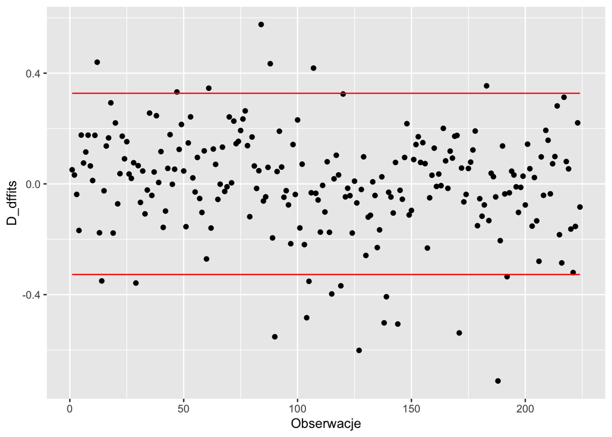

**Wnioski:** Obserwację uznajemy za wpływową, jeśli $DFFITS_i>2\sqrt{p/n}$. W naszym przypadku mamy 21 takich obserwacji. Wymagają one dodatkowej analizy.

## Zadanie 11

Do badania wielkości zjawiska multikolinearności można posłużyć się tzw. miarą Variance inflation factor (VIF). VIF dla k-tej zmiennej objaśniającej bada, w jakim stopniu zmienna $X_k$ objaśniana jest przez pozostałe zmienne objaśniające $X_1, ..., X_{k−1}, X_{k+1}, ..., X_{p−1}$. Duże wartości $VIF_k$ wskazują na bardzo silną korelację między $X_k$ i pewną kombinacją liniową pozostałych zmiennych objaśniających. Implikuje to występowanie zjawiska multikolinearności. Zamiast Variance inflation factor można stosować miarę zwaną Tolerancją, zdefiniowaną jako odwrtność VIF. W przypadku tolerancji na problem z multikolinearnością wskazywać będą wartości mniejsze od $0.1$.

```
##       HSM       HSE       HSS      SATM      SATV       SEX
## 0.5188628 0.5429546 0.5088203 0.5745498 0.7310535 0.7742519
```

**Wnioski:** Nie ma problemów z multikolinearnościom zmiennych.

## Zadanie 12

W tym zadaniu badamy wartości statystyk $AIC$ oraz $BIC$ dla niektórych podzbiorów wyżej analizowanego modelu. Kryteria AIC oraz BIC są stosujemy w celu znalezienia balansu pomiędzy dopasowaniem modelu do danych i nadmierną złożonością modelu. Wyniki dla obu kryteriów przedstawione zostały w tabeli poniżej.

```
##                                                  AIC      BIC
## model HSM                                   481.6754 491.9103
## `model HSM + HSS`                           481.1339 494.7805
## `model HSM + HSS + HSE`                     481.7550 498.8132
## `model HSM + HSS + HSE + SATM`              482.2978 502.7677
## `model HSM + HSS + HSE + SATM + SATV`       483.8105 507.6920
## `model HSM + HSS + HSE + SATM + SATV + SEX` 485.7234 513.0166
## `model SEX`                                 528.5092 538.7441
## `model SEX + SATV`                          527.3750 541.0216
## `model SEX + SATV + SATM`                   515.0302 532.0884
## `model SEX + SATV + SATM + HSE`             501.9929 522.4628
## `model SEX + SATV + SATM + HSE + HSS`       496.8881 520.7696
## `model SEX + SATV + SATM + HSE + HSS + HSM` 485.7234 513.0166
```

**Wnioski:** Statystyka BIC przyjmuje najmniejszą wartość dla modelu uwzględniającego tylko zmienną $HSM$. Według tego kryterium powinniśmy wybrać właśnie ten model. Kryterium AIC osiąga najmniejszą wartość dla modelu bazującego na HSM oraz HSS. Jednak wartość AIC dla modelu uwzględniającego jedynie $HSM$ jest również bardzo bliska tej wartości. Biorąc pod uwagę oba te kryteria, najlepszy model z podanych jaki możemy wybrać to model regresji prostej uwzględniającej $HSM$.